# 2b_ViewTimeSeriesComposite

## Make and view annual time-series data as 3-band composite

```
Basic Parameters:
 PrintDate = 2023-08-21
 gridCell = 3807
 index_dir = /home/downspout-cel/paraguay_lc/stac/grids/003807/brdf_ts/ms/ndmi
 out_dir = /home/klwalker/data/tmp
 spec_index= ndmi
Single Plot Parameters:
 plot_yr = 2021
Shapefile = poly
 If point, file is /home/klwalker/data/tmp/SelectedCoords.csv
 If poly, file is /home/downspout-cel/paraguay_lc/vector/TestPolys/YerbaMatte_GEpolysEE.shp
 input crs = epsg:8858
startYr = 2020
 endYr = 2022
```

## Current options for composite bands are:

- Avg (mean)
- Max (maximum index value)
- Min (minumum index value)
- Amp (Max - Min)
- Std (standard deviation)
- CV (coefficient of variation: std/mean)
- MaxDate (day of year on which maximum occurs)
- MaxDateCos (cosine of max date, to reduce periodic effect)
- MinDate (day of year on which minimum occurs)
- MinDateCos (cosine of min date, to reduce periodic effect)
- Jan (value from Jan 10th image)
- Apr (value from Apr 10th image)
- Jun (value from Jun 10th image)
- Aug (value from Aug 10th image)
- Nov (value from Nov 10th image)

### note: if running many these, use bash script "MakeTScomposite.sh" to run on job node of cluster

## Make ['Min','Max','Amp'] composite to highlight crops vs grassland/forest

```
11:10:21:INFO:1044:io.to_raster:  Creating the file ...

11:10:21:INFO:1051:io.to_raster:  Writing data to file ...

11:10:21:INFO:1074:io.to_raster:  Windows 1--16 of 16 ...
```

```
['Min', 'Max', 'Amp']
making max raster
```

```
11:10:24:INFO:1380:io.to_raster:
Finished writing the data.
11:10:24:INFO:1044:io.to_raster:  Creating the file ...

11:10:24:INFO:1051:io.to_raster:  Writing data to file ...

11:10:24:INFO:1074:io.to_raster:  Windows 1--16 of 16 ...
```

```
making min raster
```

```
11:10:27:INFO:1380:io.to_raster:
Finished writing the data.
11:10:27:INFO:1044:io.to_raster:  Creating the file ...

11:10:27:INFO:1051:io.to_raster:  Writing data to file ...

11:10:27:INFO:1074:io.to_raster:  Windows 1--16 of 16 ...
```

```
making amp raster
```

```
11:10:30:INFO:1380:io.to_raster:
Finished writing the data.
```

```
['/home/klwalker/data/tmp/Max.tif', '/home/klwalker/data/tmp/Min.tif', '/home/klwalker/data/tmp/Amp.tif']
```

## Non-interactive image with enhanced colors:

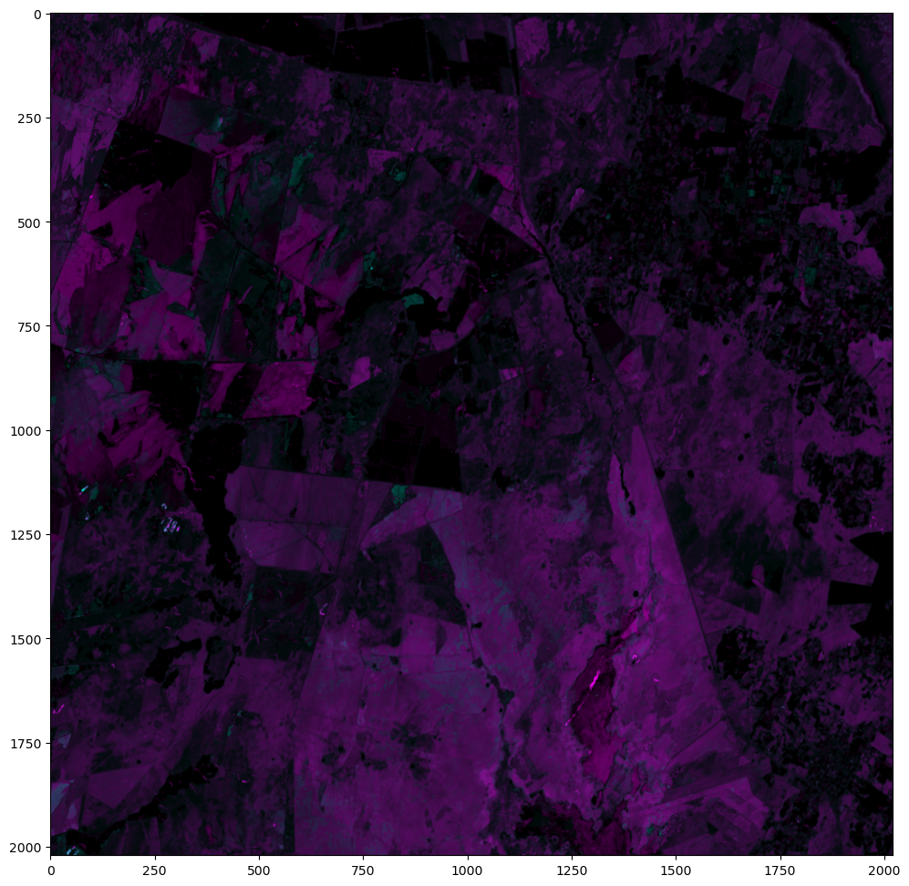

## Interactive image (to query points for timeseries profile)

```
click on map to get coordinates to query (can zoom in first)
```

```
Map(center=[-26.389379121140127, -56.50777064878126], controls=(ZoomControl(options=['position', 'zoom_in_text…
```

```
   Unnamed: 0        XCoord        YCoord        lat        lon
0           0  3.041069e+06 -3.329755e+06 -56.592916 -26.390640
1           1  3.042275e+06 -3.328298e+06 -56.581244 -26.378645
2           2  3.048250e+06 -3.329195e+06 -56.514639 -26.386026
3           3  3.048678e+06 -3.330875e+06 -56.508116 -26.399865
1: 2017/0/2017
2: 206/139/67
3: 501/0/501
4: 613/291/322
```

```
Map(bottom=604224.0, center=[-26.389379121140127, -56.50777064878126], controls=(ZoomControl(options=['positio…
```

## Get time series for pts

```
working on cell 3807
grid is in:  epsg:8858
                                            geometry
0  POLYGON ((3058830.886 -3339608.696, 3058830.88...
Of the 4 ppts, 4 are in gridCell 3807
getting index values...
                           geometry  2020153  2020162  2020172  2020183  \
0  POINT (3041069.149 -3329754.978)     1148      696      435      331
1  POINT (3042275.277 -3328298.193)     1131     1134     1133     1066
2  POINT (3048250.129 -3329194.703)      899      916      913      886
3  POINT (3048677.934 -3330875.426)      725      459      381      396

   2020192  2020202  2020214  2020223  2020233  ...  2022051  2022060  \
0      334      337      335      331      328  ...      539      539
1      968      822      673      706      833  ...      206      201
2      862      836      839      858      864  ...      501      501
3      408      421      437      460      477  ...      550      613

   2022069  2022079  2022091  2022100  2022110  2022121  2022130  2022140
0      539      539      539      539      539      539      539      539
1      206      200      200      201      201      206      200      201
2      501      500      501      501      501      501      501      501
3      493      303      291      295      299      300      300      300

[4 rows x 73 columns]
working on cell 3807
grid is in:  epsg:8858
                                            geometry
0  POLYGON ((3058830.886 -3339608.696, 3058830.88...
Of the 4 ppts, 4 are in gridCell 3807
getting index values...
                           geometry     2020194     2020242     2020274  \
0  POINT (3041069.149 -3329754.978)    0.000000         NaN  381.909548
1  POINT (3042275.277 -3328298.193)    0.000000         NaN -684.732640
2  POINT (3048250.129 -3329194.703)  884.070058  285.477865 -871.683812
3  POINT (3048677.934 -3330875.426)  521.356784   27.894003 -186.357880

       2020290      2020322      2020354  2021036      2021052      2021068  \
0   508.649626  -286.003543   938.686923      NaN  4049.550537  3766.407119
1          NaN  -545.117142   535.857105      NaN  2667.461263  2647.531573
2 -1665.563644 -1990.231990 -1701.469451      NaN -1369.714492 -1367.461431
3  -233.906824  -492.996180   745.156483      NaN  1480.621540   623.012161

   ...      2021338      2021358      2022013      2022033      2022043  \
0  ...  3869.606004  4197.937239  3407.491487  1907.267346  2517.089473
1  ...  2355.132450  2813.852814  2432.329394  1724.043341  1950.379049
2  ...  4146.341463  4415.395788  3093.783687  2339.461764  2356.408499
3  ...  1728.701406  1747.694887   808.854832   -29.394474   451.095518

       2022053      2022073  2022093      2022113      2022133
0  2224.793388  3575.195107      0.0  3392.070485  3025.228846
1  1911.827045     0.000000      0.0  2950.487760  2708.841750
2  2302.319084  2607.887673      0.0  4839.785145  4732.142857
3  -176.540993     0.000000      0.0  1664.301642  1854.187192

[4 rows x 153 columns]
```

## show output

```
Map(bottom=604224.0, center=[-26.389379121140127, -56.50777064878126], controls=(ZoomControl(options=['positio…
```

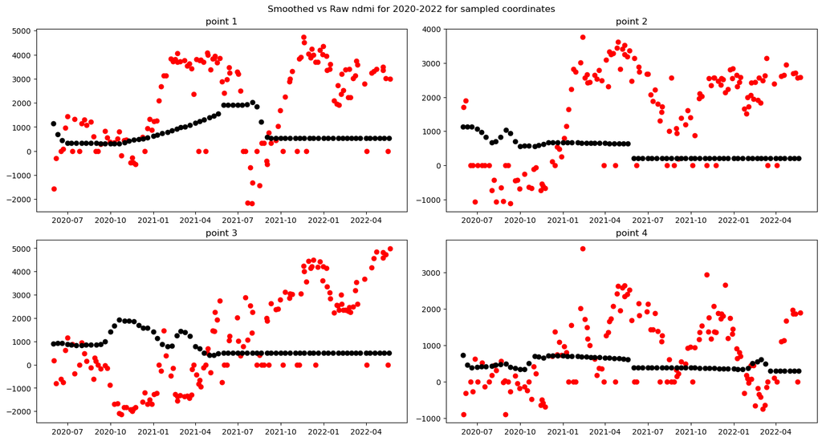

## to show one point in more detiail:

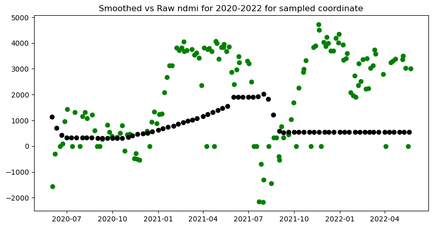

# To save an html copy of this notebook with all outputs: